# Prediction Assignment

Mats Julian Olsen

17 Feb 2015

So, let us first load our data, and check out the first few lines of the training set using the `head` command.

```r
pml.training <- read.csv("./pml-training.csv", na.strings=c('NA', '', ' '))
pml.test <- read.csv("./pml-testing.csv", na.strings=c('NA', '', ' '))
head(pml.training)
```

```
##   X user_name raw_timestamp_part_1 raw_timestamp_part_2   cvtd_timestamp
## 1 1  carlitos           1323084231               788290 05/12/2011 11:23
## 2 2  carlitos           1323084231               808298 05/12/2011 11:23
## 3 3  carlitos           1323084231               820366 05/12/2011 11:23
## 4 4  carlitos           1323084232               120339 05/12/2011 11:23
## 5 5  carlitos           1323084232               196328 05/12/2011 11:23
## 6 6  carlitos           1323084232               304277 05/12/2011 11:23
##   new_window num_window roll_belt pitch_belt yaw_belt total_accel_belt
## 1         no         11      1.41       8.07    -94.4                3
## 2         no         11      1.41       8.07    -94.4                3
## 3         no         11      1.42       8.07    -94.4                3
## 4         no         12      1.48       8.05    -94.4                3
## 5         no         12      1.48       8.07    -94.4                3
## 6         no         12      1.45       8.06    -94.4                3
##   kurtosis_roll_belt kurtosis_picth_belt kurtosis_yaw_belt
```

[output cut: 265 more lines]

Looking at our data there are multiple columns that are full of `NA`s. By inspecting more of the data, we see that the columns that have mostly `NA`s have only data when the `new_window` variable is `'yes'`. Also, judging by the variable names, some of the columns clearly represent aggregates such as `avg`, `std` and `var`. Example column names include `avg_roll_dumbbell`, `stddev_roll_dumbbell` and `var_roll_dumbbell`. Reading a bit on the provided [webpage](http://groupware.les.inf.puc-rio.br/har) and related papers, it is clear that the data is collected in rolling, overlapping time windows, and that the rows with `new_window = 'yes` holds the aggregates of either the preceeding or following rows. We face a choice of either keeping the data points where `new_window = 'yes'`, and train our machine learning model on what seems to be summary of a full motion, or omit these rows and train using the rawer data. Seeing as there are only `406` rows of data with `new_window` equal to `'yes'`, we will use the other set.

```r
pml.training <- pml.training[pml.training$new_window == 'no', ]
```

From the `head` command above we saw that there are a range of columns that are full of `NA`s. Let’s delete the columns that have no data and check how many variables that leaves us with.

```r
notAllNAs <- colSums(is.na(pml.training)) != nrow(pml.training)
pml.training <- pml.training[, notAllNAs]
pml.test <- pml.test[, notAllNAs]
dim(pml.training)
```

```
## [1] 19216    60
```

60! Alright, we just deleted 100 columns. Wow! Now, let’s explore some of the remaining variables.

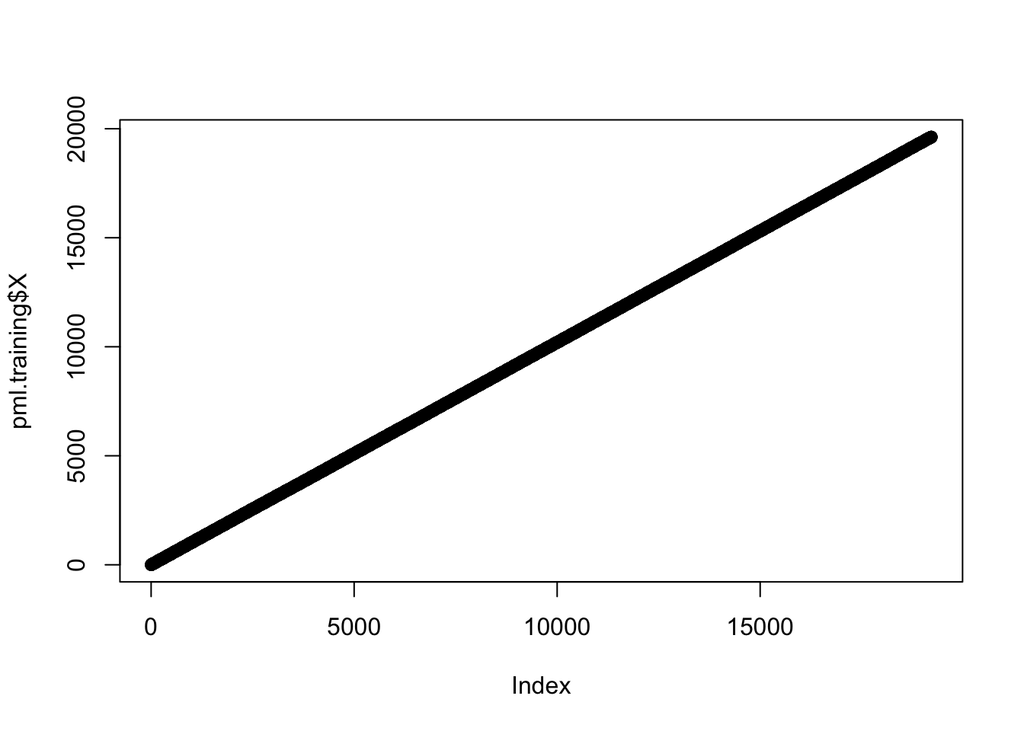

```r
plot(pml.training$X)
```

X is clearly just the index of of the samples. The column `num_window` has a cyclic relationship with `classe`, as seen in the following plot.

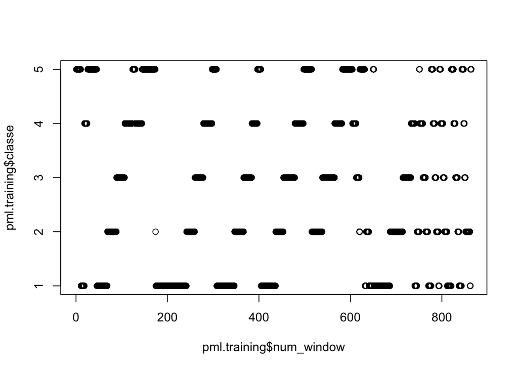

```r
plot(pml.training$num_window, pml.training$classe)
```

We’ll add that, along with `user_name` and `new_window`, which is all ‘no’ now, and all timestamp fields to the variables that we will delete.

```r
pml.training$X <- NULL
pml.training$user_name <- NULL
pml.training$raw_timestamp_part_1 <- NULL
pml.training$raw_timestamp_part_2 <- NULL
pml.training$cvtd_timestamp <- NULL
pml.training$num_window <- NULL
pml.training$new_window <- NULL
```

We’ll have to do it for our test set as well.

```r
pml.test$X <- NULL
pml.test$user_name <- NULL
pml.test$raw_timestamp_part_1 <- NULL
pml.test$raw_timestamp_part_2 <- NULL
pml.test$cvtd_timestamp <- NULL
pml.test$num_window <- NULL
pml.test$new_window <- NULL
```

```r
fit <- randomForest(classe ~ ., data=pml.training)
fit
```

```
##
## Call:
##  randomForest(formula = classe ~ ., data = pml.training)
##                Type of random forest: classification
##                      Number of trees: 500
## No. of variables tried at each split: 7
##
##         OOB estimate of  error rate: 0.29%
## Confusion matrix:
##      A    B    C    D    E  class.error
## A 5469    1    0    0    1 0.0003655639
## B   10 3704    4    0    0 0.0037654653
## C    0   10 3340    2    0 0.0035799523
## D    0    0   21 3124    2 0.0073085478
## E    0    0    1    3 3524 0.0011337868
```

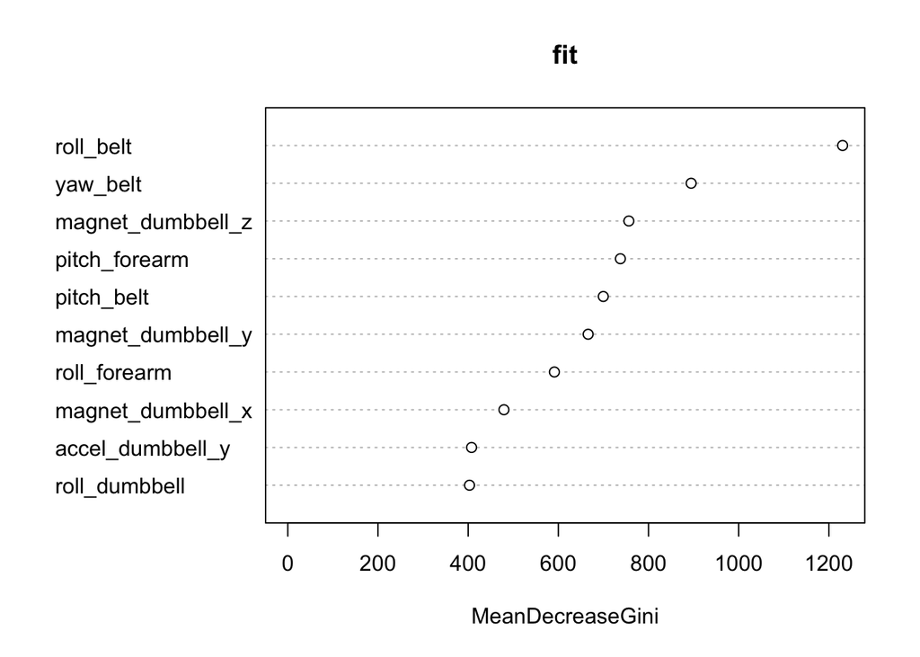

```r
varImpPlot(fit, n.var=10)
```

Clearly the `roll_belt` and `yaw_belt` variabels are the most important. Anways, let’s just do some predictions on the test set, and submit our answers.

```r
predictions <- predict(fit, newdata=pml.test)
predictions
```

```
##  1  2  3  4  5  6  7  8  9 10 11 12 13 14 15 16 17 18 19 20
##  B  A  B  A  A  E  D  B  A  A  B  C  B  A  E  E  A  B  B  B
## Levels: A B C D E
```